# Assignment10

Yiman Liu

### 1.(25 pts) Create a normalized (BCNF) relational schema and visualize the schema in an ERD for the data in the XML file. Include the ERD in your R Notebook.

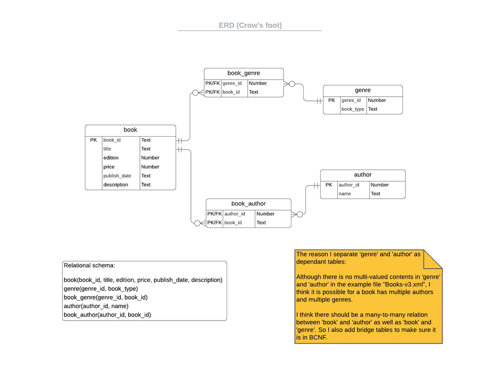

### 2.(25 pts) Create a SQLite database that implement the schema, i.e., define the tables with CREATE TABLE. Use SQL chunks in your R Notebook.

```r
library(RSQLite)

# connect to the SQLite database in the specified file
con <- dbConnect(SQLite(), dbname="/Users/liuyiman/database/my_db")
```

```sql
CREATE TABLE IF NOT EXISTS book (
  book_id TEXT PRIMARY KEY NOT NULL,
  title TEXT,
  edition INTEGER,
  price INTEGER,
  publish_date TEXT,
  description TEXT
);
```

```sql
CREATE TABLE IF NOT EXISTS genre (
  genre_id INTEGER PRIMARY KEY NOT NULL,
  book_type TEXT
);
```

```sql
CREATE TABLE IF NOT EXISTS book_genre (
  genre_id INTEGER NOT NULL,
  book_id TEXT NOT NULL,
  PRIMARY KEY (genre_id, book_id),
  FOREIGN KEY (genre_id)
    REFERENCES genre (genre_id)
        ON DELETE RESTRICT
        ON UPDATE RESTRICT,
  FOREIGN KEY (book_id)
    REFERENCES book (book_id)
        ON DELETE RESTRICT
        ON UPDATE RESTRICT
);
```

```sql
CREATE TABLE IF NOT EXISTS author (
  author_id INTEGER PRIMARY KEY NOT NULL,
  name TEXT
);
```

```sql
CREATE TABLE IF NOT EXISTS book_author (
  author_id INTEGER NOT NULL,
  book_id TEXT NOT NULL,
  PRIMARY KEY (author_id, book_id),
  FOREIGN KEY (author_id)
    REFERENCES author (author_id)
        ON DELETE RESTRICT
        ON UPDATE RESTRICT,
  FOREIGN KEY (book_id)
    REFERENCES book (book_id)
        ON DELETE RESTRICT
        ON UPDATE RESTRICT
);
```

### 3.(25 pts) Load the XML data from the file into R data frames; you will need to use either node-by-node traversal of the XML tree or a combination of node-by-node traversal with XPath; you likely will not be able to accomplish it with only XPath. Use surrogate keys and/or the ID attributes in the XML.

```r
library(XML)
doc = xmlParse(file = "Books-v3.xml")
df <- xmlToDataFrame(doc)

library(XML)
library(methods)

# load xml file into R
data = xmlParse(file = "Books-v3.xml")
book_id_data <- xpathSApply(data, "/catalog/book/@id")
df$book_id = book_id_data

df <- df[c("book_id", "author", "title", "genre", "price", "publish_date", "description", "edition")]
print(df)
```

| book_id | author | title | genre | price | publish_date | description | edition |
| --- | --- | --- | --- | --- | --- | --- | --- |
| bk101 | Gambardella, Matthew | XML Developer's Guide | Computer | 44.95 | 2000-10-01 | An in-depth look at creating applications \n with XML. | NA |
| bk102 | Ralls, Kim | Midnight Rain | Fantasy | 5.95 | 2000-12-16 | A former architect battles corporate zombies, \n an evil sorceress, and her own childhood to become queen \n of the world. | NA |
| bk103 | Corets, Eva | Maeve Ascendant | Fantasy | 5.95 | 2000-11-17 | After the collapse of a nanotechnology \n society in England, the young survivors lay the \n foundation for a new society. | NA |
| bk104 | Corets, Eva | Oberon's Legacy | Fantasy | 5.95 | 2001-03-10 | In post-apocalypse England, the mysterious \n agent known only as Oberon helps to create a new life \n for the inhabitants of London. Sequel to Maeve \n Ascendant. | NA |
| bk105 | Corets, Eva | The Sundered Grail | Fantasy | 5.95 | 2001-09-10 | The two daughters of Maeve, half-sisters, \n battle one another for control of England. Sequel to \n Oberon's Legacy. | NA |
| bk106 | Randall, Cynthia | Lover Birds | Romance | 4.95 | 2000-09-02 | When Carla meets Paul at an ornithology \n conference, tempers fly as feathers get ruffled. | NA |
| bk148 | Galos, Mike | Visual Studio | Computer | 69.95 | 2008-09-01 | A comprehensive\n Guide to Microsoft's development environment. | NA |
| bk107 | Thurman, Paula | Splish Splash | Romance | 4.95 | 2000-11-02 | A deep sea diver finds true love twenty \n thousand leagues beneath the sea. | NA |
| bk108 | Knorr, Stefan | Creepy Crawlies | Horror | 4.95 | 2000-12-06 | An anthology of horror stories about roaches,\n centipedes, scorpions and other insects. | NA |
| bk109 | Kress, Peter | Paradox Lost | Science Fiction | 6.95 | 2000-11-02 | After an inadvertant trip through a Heisenberg\n Uncertainty Device, James Salway discovers the problems \n of being quantum. | NA |

[output cut: 6 more lines]

### 4.(25 pts) Transform data types as necessary and then write the data frames to the appropriate tables in the database.

```r
library(dplyr)
library(magrittr)
# change data type
df %<>%
  mutate(publish_date= as.Date(publish_date))
df %<>%
  mutate(edition= as.numeric(edition))
df %<>%
  mutate(price= as.numeric(price))
print(df)
```

| book_id | author | title | genre | price | publish_date | description | edition |
| --- | --- | --- | --- | --- | --- | --- | --- |
| bk101 | Gambardella, Matthew | XML Developer's Guide | Computer | 44.95 | 2000-10-01 | An in-depth look at creating applications \n with XML. | NA |
| bk102 | Ralls, Kim | Midnight Rain | Fantasy | 5.95 | 2000-12-16 | A former architect battles corporate zombies, \n an evil sorceress, and her own childhood to become queen \n of the world. | NA |
| bk103 | Corets, Eva | Maeve Ascendant | Fantasy | 5.95 | 2000-11-17 | After the collapse of a nanotechnology \n society in England, the young survivors lay the \n foundation for a new society. | NA |
| bk104 | Corets, Eva | Oberon's Legacy | Fantasy | 5.95 | 2001-03-10 | In post-apocalypse England, the mysterious \n agent known only as Oberon helps to create a new life \n for the inhabitants of London. Sequel to Maeve \n Ascendant. | NA |
| bk105 | Corets, Eva | The Sundered Grail | Fantasy | 5.95 | 2001-09-10 | The two daughters of Maeve, half-sisters, \n battle one another for control of England. Sequel to \n Oberon's Legacy. | NA |
| bk106 | Randall, Cynthia | Lover Birds | Romance | 4.95 | 2000-09-02 | When Carla meets Paul at an ornithology \n conference, tempers fly as feathers get ruffled. | NA |
| bk148 | Galos, Mike | Visual Studio | Computer | 69.95 | 2008-09-01 | A comprehensive\n Guide to Microsoft's development environment. | NA |
| bk107 | Thurman, Paula | Splish Splash | Romance | 4.95 | 2000-11-02 | A deep sea diver finds true love twenty \n thousand leagues beneath the sea. | NA |
| bk108 | Knorr, Stefan | Creepy Crawlies | Horror | 4.95 | 2000-12-06 | An anthology of horror stories about roaches,\n centipedes, scorpions and other insects. | NA |
| bk109 | Kress, Peter | Paradox Lost | Science Fiction | 6.95 | 2000-11-02 | After an inadvertant trip through a Heisenberg\n Uncertainty Device, James Salway discovers the problems \n of being quantum. | NA |

[output cut: 6 more lines]

```r
# loading data from dataframe into book table
for(i in 1:nrow(df)){
  write_sql <- paste("Insert into book (book_id, title, edition, price, publish_date, description) values (", '"', df[i, "book_id"], '"', ",", '"', df[i, "title"], '"', ",", '"', df[i, "edition"], '"', ",", '"', df[i, "price"], '"', ",", '"', df[i, "publish_date"], '"', ",", '"', df[i, "description"], '"', ")",seq = "")
  dbSendQuery(con, write_sql)
}
```

```r
x <- data.frame(c(df["author"]))
x <- unique(x)
```

```r
# loading data from dataframe into author table
for(i in 1:nrow(x)){
  write_sql <- paste("Insert into author (name) values (", '"', x[i, "author"], '"', ")",seq = "")
  dbSendQuery(con, write_sql)
}
```

```r
# loading data from dataframe into bridge table (book_author)
book_author <- data.frame(
  author_id = c(1,2,3,3,3,4,5,6,7,8,5,9,9,9,5,3),
  book_id = c(df["book_id"])
)
# loading data from dataframe into book_author table
for(i in 1:nrow(book_author)){
  write_sql <- paste("Insert into book_author (author_id, book_id) values (", book_author[i, "author_id"], ",", '"', book_author[i, "book_id"], '"', ")",seq = "")
  dbSendQuery(con, write_sql)
}
```

```r
y <- data.frame(c(df["genre"]))
y <- unique(y)
```

```r
# loading data from dataframe into genre table
for(i in 1:nrow(y)){
  write_sql <- paste("Insert into genre (book_type) values (", '"', y[i, "genre"], '"', ")",seq = "")
  dbSendQuery(con, write_sql)
}
```

```r
# loading data from dataframe into bridge table (book_genre)
book_genre <- data.frame(
  genre_id = c(1,2,2,2,2,3,1,3,4,5,1,1,1,1,1,2),
  book_id = c(df["book_id"])
)
# loading data from dataframe into book_genre table
for(i in 1:nrow(book_genre)){
  write_sql <- paste("Insert into book_genre (genre_id, book_id) values (", book_genre[i, "genre_id"], ",", '"', book_genre[i, "book_id"], '"', ")",seq = "")
  dbSendQuery(con, write_sql)
}
```

### 5.(25 pts) Once the data from the XML is in the database, build SQL chunks for the following queries:

- **What are the titles and prices of all books written by “Galos, Mike”? List the titles and the prices.**

```sql
SELECT title, price FROM book
INNER JOIN book_author ON book.book_id = book_author.book_id
INNER JOIN author ON author.author_id = book_author.author_id
WHERE author.name LIKE "%Galos, Mike%";
```

| title | price |
| --- | --- |
| Visual Studio | 69.95 |
| Visual Basic for Beginners | 29.95 |
| Visual Studio 7: A Comprehensive Guide | 49.95 |

- **What is the most recent year of publication of all books written by “O’Brien, Tim”.**

```sql
SELECT MAX(publish_date) as mostRecentYear FROM book
INNER JOIN book_author ON book.book_id = book_author.book_id
INNER JOIN author ON author.author_id = book_author.author_id
WHERE author.name LIKE "%O'Brien, Tim%";
```

| mostRecentYear |
| --- |
| 2009-10-01 |

- **What is the average price of all books in the “Fantasy” genre.**

```sql
SELECT AVG(price) as averagePrice FROM book
INNER JOIN book_genre ON book.book_id = book_genre.book_id
INNER JOIN genre ON genre.genre_id = book_genre.genre_id
WHERE genre.book_type LIKE "%Fantasy%";
```

| averagePrice |
| --- |
| 6.35 |

- **Find the number of books in each genre.**

```sql
SELECT book_type, COUNT(*) as cnt FROM book
INNER JOIN book_genre ON book.book_id = book_genre.book_id
INNER JOIN genre ON genre.genre_id = book_genre.genre_id
GROUP BY book_type;
```

| book_type | cnt |
| --- | --- |
| Computer | 7 |
| Fantasy | 5 |
| Horror | 1 |
| Romance | 2 |
| Science Fiction | 1 |

- **List the title and author of all books that cost less than the average price of books.**

```sql
SELECT title, name as author FROM book
INNER JOIN book_author ON book.book_id = book_author.book_id
INNER JOIN author ON author.author_id = book_author.author_id
WHERE book.price < (
  SELECT AVG(price) FROM book
);
```

| title | author |
| --- | --- |
| Midnight Rain | Ralls, Kim |
| Maeve Ascendant | Corets, Eva |
| Oberon's Legacy | Corets, Eva |
| The Sundered Grail | Corets, Eva |
| Lover Birds | Randall, Cynthia |
| Splish Splash | Thurman, Paula |
| Creepy Crawlies | Knorr, Stefan |
| Paradox Lost | Kress, Peter |
| Oberon's Revenge | Corets, Eva |